# “Reproducible Research: Peer Assessment 1”

## by ‘Gopalkriz’

### Date:

```
## [1] "2015-08-12"
```

### Coursera - Reproducible Research (Aug 2015 batch)

## Project Introduction

### Dataset: https://d396qusza40orc.cloudfront.net/repdata%2Fdata%2Factivity.zip

### ProjectFolder: https://github.com/gopalkriz/RepData_PeerAssessment1

### Local Repository:

```
## [1] "Cloned from github D:/VIVEK/DataAnalysis/Coursera/5 RepRes/RepData_PeerAssessment1"
```

## Setting Global Options

arguments set for code chunks to be included in output

```r
library(knitr)
opts_chunk$set(echo = TRUE, results = "asis")
```

## Set Working Directory with required Folder Path

```r
WDoriginal <- getwd()
setwd("D:/VIVEK/DataAnalysis/Coursera/5 RepRes/RepData_PeerAssessment1")
```

## Project Introduction

About: “quantified self” movement - collect data of personal activity using monitoring devices Data: collected at 5 minute intervals through out the day for two months from an anonymous individual during October and November, 2012. Variable: steps taken in 5 minute intervals each day.

Dataset: https://d396qusza40orc.cloudfront.net/repdata%2Fdata%2Factivity.zip ProjectFolder: https://github.com/gopalkriz/RepData_PeerAssessment1 Local Repository: [1] “Cloned from github D:/VIVEK/DataAnalysis/Coursera/5 RepRes/RepData_PeerAssessment1”

## Loading and preprocessing the data

### Upload the Data

```r
unzip("activity.zip")
Data <- read.csv("activity.csv", header = TRUE, sep =",")
```

### Understand the Data

dataset: comma-separated-value (CSV) file 17,568 observations Three variables included in this dataset are: steps: taking in a 5-minute interval (missing values are coded as NA) date: on which the measurement was taken in YYYY-MM-DD format interval: continuous counter Identifier of time for the measurement

```r
object.size(Data)
```

214232 bytes

```r
class(Data)
```

[1] “data.frame”

```r
dim(Data); nrow(Data); ncol(Data)
```

[1] 17568 3 [1] 17568 [1] 3

```r
names(Data)
```

[1] “steps” “date” “interval”

```r
str(Data)
```

‘data.frame’: 17568 obs. of 3 variables: $ steps : int NA NA NA NA NA NA NA NA NA NA … $ date : Factor w/ 61 levels “2012-10-01”,“2012-10-02”,..: 1 1 1 1 1 1 1 1 1 1 … $ interval: int 0 5 10 15 20 25 30 35 40 45 …

```r
head(Data)
```

steps date interval 1 NA 2012-10-01 0 2 NA 2012-10-01 5 3 NA 2012-10-01 10 4 NA 2012-10-01 15 5 NA 2012-10-01 20 6 NA 2012-10-01 25

```r
tail(Data)
```

```
  steps       date interval
```

17563 NA 2012-11-30 2330 17564 NA 2012-11-30 2335 17565 NA 2012-11-30 2340 17566 NA 2012-11-30 2345 17567 NA 2012-11-30 2350 17568 NA 2012-11-30 2355

```r
summary(Data)
```

```
 steps                date          interval
```

Min. : 0.00 2012-10-01: 288 Min. : 0.0  
1st Qu.: 0.00 2012-10-02: 288 1st Qu.: 588.8  
Median : 0.00 2012-10-03: 288 Median :1177.5  
Mean : 37.38 2012-10-04: 288 Mean :1177.5  
3rd Qu.: 12.00 2012-10-05: 288 3rd Qu.:1766.2  
Max. :806.00 2012-10-06: 288 Max. :2355.0  
NA’s :2304 (Other) :15840

## Question 1.0

### What is mean total number of steps taken per day?

note: you can ignore the missing values in the dataset

1.1. Calculate the total number of steps taken per day ### Rcode 1.1

```r
daysteps <- aggregate(steps ~ date, data = Data, FUN = sum)
```

1.2. Plot the total number of steps taken per day

Barplot steps-datewise ### Rcode 1.2a

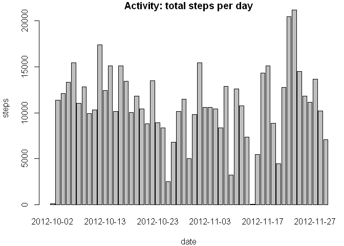

```r
par(mfrow = c(1, 1))
par(mar=c(4,4,1,0.5))

plot_001 <- barplot(daysteps$steps, names.arg = daysteps$date, xlab = "date", ylab = "steps", main = "Activity: total steps per day")
```

```r
dev.copy(png,'plot_001.png')
```

png 3

```r
invisible(plot_001)
dev.off()
```

png 2

Histogram steps per day ### Rcode 1.2b

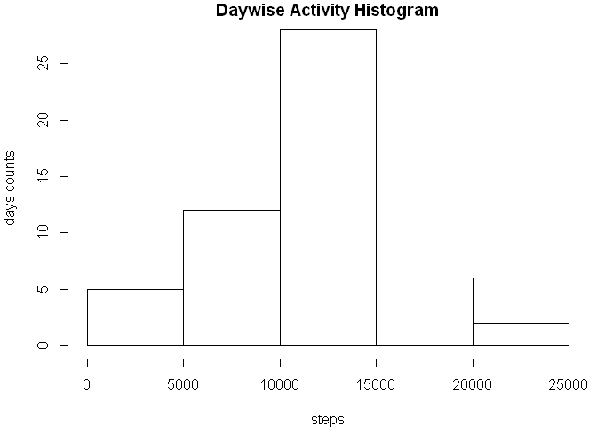

```r
par(mfrow = c(1, 1))
par(mar=c(4,4,1,0.5))

plot_002 <- hist(daysteps$steps, xlab = "steps", ylab = "days counts", main ="Daywise Activity Histogram") # Histogram of steps per day
```

```r
dev.copy(png,'plot_002.png')
```

png 3

```r
invisible(plot_002)
dev.off()
```

png 2

1.3. Calculate and report the mean and median of the total number of steps taken per day ### Rcode 1.3

```r
mean(daysteps$steps) #Ans: should be 10766.19
```

[1] 10766.19

```r
median(daysteps$steps) #Ans:  should be 10765
```

[1] 10765